# GEO DNAm Data

Extract all 450k, EPIC, EPICv2 datasets

Paul Yousefi

19 October 2026

# Purpose

To identify and access all available DNAm datasets provided by the Gene Expression Omnibus (GEO) https://www.ncbi.nlm.nih.gov/geo/.

While addition eligibility criteria are discussed further below, datasets needed to have been run in humans on an omic-level DNA methylation microarray (450k, EPIC, EPICv2) to have even been considered.

# Methods

Used functions included in the `geograbi` package (https://github.com/yousefi138/geograbi) to query and extract all data hosted on GEO

Used `geograbi.retrieve.datasets()` to query GEO for experiment records meeting the following selection criteria:

- Human subjects
- DNAm array data available on an omic-level platform (450k, EPIC, EPICv2)
- N >100

## Human DNAm Array experiments with N>100

N = 875 experiments meeting our inclusion criteria

Complete metadata about all results is detailed in `gses.csv`

### Blood DNAm data

From the records above with successfully extracted DNAm data, there are N = 165 experiments where we are confident that measurements for **all samples** were performed in blood.

Complete metadata about this subset is available in `blood.gses.csv`, including paths to all relevant related files.

For example:

- `dnam.file` - path to the experiment’s DNAm data `.csv.gz` file
- `samples.file` - path to experiments’s sample/patient information data matrix

The total number of samples from these experiments is:

```r
sum(blood.gses$samples)
```

```
> [1] 69548
```

Histogram of samples per experiment of successfully downloaded GEO experiments to date:

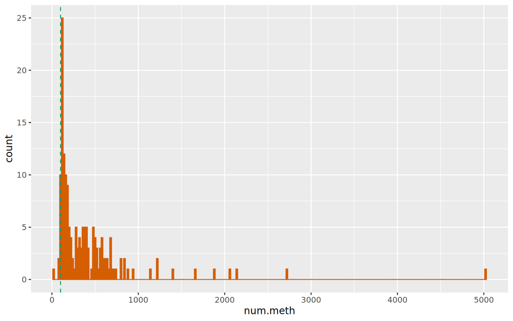

The frequency of experiments using each microarray platform was as follows:

| platform | n | percent |
| --- | --- | --- |
| GPL13534 | 84 | 50.9 |
| GPL16304 | 5 | 3.0 |
| GPL21145 | 67 | 40.6 |
| GPL23976 | 5 | 3.0 |
| GPL33022 | 4 | 2.4 |
| Total | 165 | 99.9 |